# projectDraft

```r
data = read_csv("drug_consumption.csv")
head(data, n = 3)
```

```
## # A tibble: 3 × 32
##      ID     Age Gender Education Country Ethnicity Nscore Escore Oscore Ascore
##   <dbl>   <dbl>  <dbl>     <dbl>   <dbl>     <dbl>  <dbl>  <dbl>  <dbl>  <dbl>
## 1     1  0.498   0.482   -0.0592   0.961     0.126  0.313 -0.575 -0.583 -0.917
## 2     2 -0.0785 -0.482    1.98     0.961    -0.317 -0.678  1.94   1.44   0.761
## 3     3  0.498  -0.482   -0.0592   0.961    -0.317 -0.467  0.805 -0.847 -1.62
## # ℹ 22 more variables: Cscore <dbl>, Impulsive <dbl>, SS <dbl>, Alcohol <chr>,
## #   Amphet <chr>, Amyl <chr>, Benzos <chr>, Caff <chr>, Cannabis <chr>,
## #   Choc <chr>, Coke <chr>, Crack <chr>, Ecstasy <chr>, Heroin <chr>,
## #   Ketamine <chr>, Legalh <chr>, LSD <chr>, Meth <chr>, Mushrooms <chr>,
## #   Nicotine <chr>, Semer <chr>, VSA <chr>
```

# Prior Notes:

- Variables are standardized numerically by variance of values in the dataset.
- For readability They need to be reinitialized with their actual values.

# Preprocessing

- 20241204-MTL:
- I’m going to first look at the distributions of what drug each person consumes.
- I’m also going to make a graph so that we can visually see the distribution of types of drug consumption between different persons.
- Then I’ll attempt to run other analysis as necessary.

## Initialize Dataset for Readability and Other Uses

```r
# Saved list of age ranges for later use
age = c("18-24", "25-34", "35-44", "45-54", "55-64", "65+")
cat("age_range_variance=",length(age), "\n")
```

```
## age_range_variance= 6
```

```r
# Save list of drugs for later use
drugs = c("Alcohol", "Amphet", "Amyl", "Benzos", "Caff", "Cannabis", "Choc", "Coke", "Crack", "Ecstasy", "Heroin", "Ketamine", "Legalh", "LSD", "Meth","Mushrooms", "Nicotine", "Semer", "VSA")

cat("total_drugs=",length(drugs))
```

```
## total_drugs= 19
```

```r
# 20241204-MTL: I'm also going to clean the data into a new variable separate from
#               the original data (so that the original data will still be
#               accessible), it may be unnecessary and the process may be time
#               consuming, but it will make it more readable for other uses if
#               needed. It's better to have clean readable data vs numerical values
#               that make it harder to distinguish its value in the data.


# ********************** Initialize Values **************************
Data = data %>%
  mutate(

### Initialize Age
    Age = case_when(
      Age == -0.95197 ~ "18-24",
      Age == -0.07854 ~ "25-34",
      Age == 0.49788 ~ "35-44",
      Age == 1.09449 ~ "45-54",
      Age == 1.82213 ~ "55-64",
      Age == 2.59171 ~ "65+"
    ),

### Make Gender Binary (clean the data);
# **** 0==Male(-0.48246), 1==Female (0.48246)
    Gender = case_when(
      Gender >= 0 ~ 1, # female
      Gender < 0 ~ 0   # male
    ),

### Initialize Education
    Education = case_when(
      Education == -2.43591 ~ "Left School Before 16 years",
      Education == -1.73790 ~ "Left School at 16 years",
      Education == -1.43719 ~ "Left School at 17 years",
      Education == -1.22751 ~ "Left School at 18 years",
      Education == -0.61113 ~ "Some College,No Certificate Or Degree",
      Education == -0.05921 ~ "Professional Certificate/ Diploma",
      Education == 0.45468 ~ "University Degree",
      Education == 1.16365 ~ "Masters Degree",
      Education == 1.98437 ~ "Doctorate Degree",
    ),

### Initialize Country
    Country = case_when(
      Country == -0.09765 ~"Australia",
      Country == 0.24923 ~"Canada",
      Country == -0.46841 ~"New Zealand",
      Country == -0.28519 ~"Other",
      Country == 0.21128 ~"Republic of Ireland",
      Country == 0.96082 ~"UK",
      Country == -0.57009 ~"USA"
    ),

### Initialize Ethnicity
    Ethnicity = case_when(
      Ethnicity == -0.50212 ~ "Asian",
      Ethnicity == -1.10702 ~ "Black",
      Ethnicity == 1.90725 ~ "Mixed-Black/Asian",
      Ethnicity == 0.12600 ~ "Mixed-White/Asian",
      Ethnicity == -0.22166 ~ "Mixed-White/Black",
      Ethnicity == 0.11440 ~ "Other",
      Ethnicity == -0.31685 ~ "White"
    )

# The Behavior score values will not be initialized, their numbers
# are standardized based on overall variance. (It will also be time consuming to relabel the values.)

  )

head(Data, 5)
```

```
## # A tibble: 5 × 32
##      ID Age   Gender Education    Country Ethnicity Nscore Escore  Oscore Ascore
##   <dbl> <chr>  <dbl> <chr>        <chr>   <chr>      <dbl>  <dbl>   <dbl>  <dbl>
## 1     1 35-44      1 Professiona… UK      Mixed-Wh…  0.313 -0.575 -0.583  -0.917
## 2     2 25-34      0 Doctorate D… UK      White     -0.678  1.94   1.44    0.761
## 3     3 35-44      0 Professiona… UK      White     -0.467  0.805 -0.847  -1.62
## 4     4 18-24      1 Masters Deg… UK      White     -0.149 -0.806 -0.0193  0.590
## 5     5 35-44      1 Doctorate D… UK      White      0.735 -1.63  -0.452  -0.302
## # ℹ 22 more variables: Cscore <dbl>, Impulsive <dbl>, SS <dbl>, Alcohol <chr>,
## #   Amphet <chr>, Amyl <chr>, Benzos <chr>, Caff <chr>, Cannabis <chr>,
## #   Choc <chr>, Coke <chr>, Crack <chr>, Ecstasy <chr>, Heroin <chr>,
## #   Ketamine <chr>, Legalh <chr>, LSD <chr>, Meth <chr>, Mushrooms <chr>,
## #   Nicotine <chr>, Semer <chr>, VSA <chr>
```

```r
### Initialize Consumption Values
# *** Consumption is based on a rating scale from 0-6
# *** @JonChang; 20241204-MTL:  I see that you've added a drug usage in your code
#                               which regards those who selected > (greater than) 3 as 1: regular usage
#                               and those < (less than) 3 are encoded as 0: non-regular. The non-regular
#                               is a bit vague, as non-regular could mean more than the norm or less than
#                               the norm. In this case, it would be better to just say less-regular, I'm
#                               assuming that you plan to create a usage column to asses each individual
#                               persons' consumption of a drug.

# Consumption values will be encoded as 0:less-regular, 1:regular.
# Note a categorical values isn't truly necessary, also if the values are numerical
# it simplifies coding the data. (you can just think of 0 as not regular, and 1 as regular)
Data <- Data %>%
  mutate(
    across(all_of(drugs), ~ case_when(
      . == "CL0" ~ 0,
      . == "CL1" ~ 0,
      . == "CL2" ~ 0,
      . == "CL3" ~ 0,
      . == "CL4" ~ 1,
      . == "CL5" ~ 1,
      . == "CL6" ~ 1
    ))
  ) %>% select( # removing the behavioral scores
    -Nscore,
    -Escore,
    -Oscore,
    -Ascore,
    -Cscore,
    -Impulsive,
    -SS
  )
head(Data, 10)
```

```
## # A tibble: 10 × 25
##       ID Age   Gender Education    Country Ethnicity Alcohol Amphet  Amyl Benzos
##    <dbl> <chr>  <dbl> <chr>        <chr>   <chr>       <dbl>  <dbl> <dbl>  <dbl>
##  1     1 35-44      1 Professiona… UK      Mixed-Wh…       1      0     0      0
##  2     2 25-34      0 Doctorate D… UK      White           1      0     0      0
##  3     3 35-44      0 Professiona… UK      White           1      0     0      0
##  4     4 18-24      1 Masters Deg… UK      White           1      0     0      0
##  5     5 35-44      1 Doctorate D… UK      White           1      0     0      0
##  6     6 65+        1 Left School… Canada  White           0      0     0      0
##  7     7 45-54      0 Masters Deg… USA     White           1      0     0      0
##  8     8 35-44      0 Left School… UK      White           1      0     0      0
##  9     9 35-44      1 Professiona… Canada  White           1      0     0      0
## 10    10 55-64      0 Masters Deg… UK      White           1      0     0      0
## # ℹ 15 more variables: Caff <dbl>, Cannabis <dbl>, Choc <dbl>, Coke <dbl>,
## #   Crack <dbl>, Ecstasy <dbl>, Heroin <dbl>, Ketamine <dbl>, Legalh <dbl>,
## #   LSD <dbl>, Meth <dbl>, Mushrooms <dbl>, Nicotine <dbl>, Semer <dbl>,
## #   VSA <dbl>
```

# Proportion of Drug Consumption

## Proportions of Drug Use Across All Age Groups

```r
nTotal = nrow(Data) # total amount of rows or observations of persons
cat("observations=", nTotal, "\n")  # should be 1885 obs.
```

```
## observations= 1885
```

```r
usage_prop = c() # list the the proportions of each drug used within the dataset
for (val in drugs) {
  drugSum = sum(Data[[val]])
  drugProp = drugSum / nTotal
  usage_prop = append(usage_prop, drugProp)
}

cat("usage_prop_variance=", length(usage_prop), "\n\n") # should expect to have 19 proportions
```

```
## usage_prop_variance= 19
```

```r
cat("usage_prop_contents=\n", usage_prop)
```

```
## usage_prop_contents=
##  0.8228117 0.1262599 0.02175066 0.1586207 0.935809 0.4180371 0.9474801 0.08435013 0.01061008 0.127321 0.02811671 0.04190981 0.1278515 0.08806366 0.09071618 0.08435013 0.464191 0.000530504 0.01803714
```

```r
# The overall proportions across all age groups
drugProps = tibble(
  Drugs = drugs,
  usageProp = usage_prop
) %>% arrange(desc(usageProp))
drugProps
```

```
## # A tibble: 19 × 2
##    Drugs     usageProp
##    <chr>         <dbl>
##  1 Choc       0.947
##  2 Caff       0.936
##  3 Alcohol    0.823
##  4 Nicotine   0.464
##  5 Cannabis   0.418
##  6 Benzos     0.159
##  7 Legalh     0.128
##  8 Ecstasy    0.127
##  9 Amphet     0.126
## 10 Meth       0.0907
## 11 LSD        0.0881
## 12 Coke       0.0844
## 13 Mushrooms  0.0844
## 14 Ketamine   0.0419
## 15 Heroin     0.0281
## 16 Amyl       0.0218
## 17 VSA        0.0180
## 18 Crack      0.0106
## 19 Semer      0.000531
```

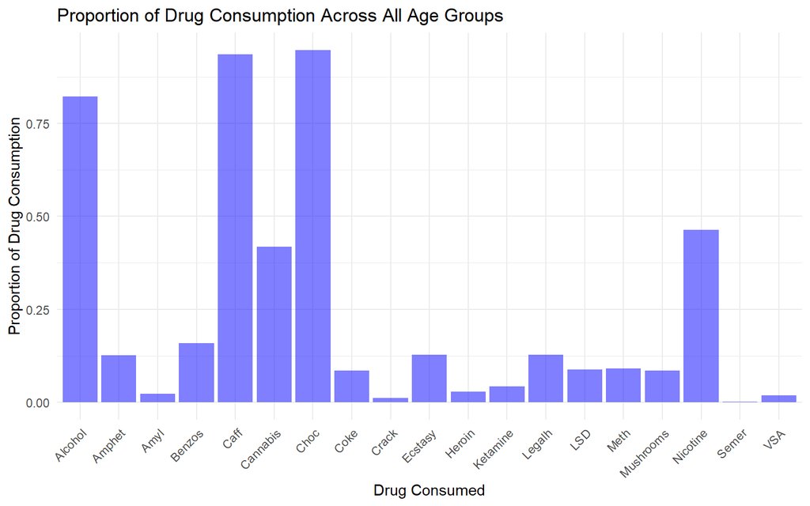

```r
# The bar plot of the proportions of drug usage across all age groups
ggplot(drugProps, aes(x = Drugs, y = usageProp)) +
  geom_bar(stat="identity",fill='blue', alpha=0.5)+
  theme(axis.text.x = element_text(angle=45, hjust=1)) +
  labs(
    title="Proportion of Drug Consumption Across All Age Groups",
    x = "Drug Consumed",
    y = "Proportion of Drug Consumption"
  )
```

> Accross our data the most used drugs are (1) chocolate, (2), caffiene, and (3) alcohol.

## Proportions of Drug Use by Different Age Groups

```r
#It's best to filter the data by age group then take the proportions
ageGroups_Use = list()
nTotals = c()

for (val in age) {
  ageDrug <- Data %>%
    filter(Age == val)

  ageGroups_Use[[as.character(val)]] = ageDrug

  n = nrow(ageDrug)
  nTotals = append(nTotals, n)
}

# Check variances
cat("nTotals_Variance=", length(nTotals), "\n")       # Number of unique age groups
```

```
## nTotals_Variance= 6
```

```r
cat("ageGroups_Use_Variance=", length(ageGroups_Use), "\n") # Total rows
```

```
## ageGroups_Use_Variance= 6
```

```r
# create list containing bar plots
barPlots = list()
```

- In total there are 6 different age groups, which requires assessing the each of the drug usage proportions among their group.
- In total there should be 6 barplots to create, as well as 6 smooth plots to compare. We can also test different plots for better visuals.

```r
# create a loop that can:
# 1. create a dataframe with all the different proportions of drug usage on drug type
# 2. create plots from the dataframes
ageGroup_Prop_DFS = list() # will contain a data frame consisting of the drug consumption proportions by age group

barPlot = list()

for (i in seq(1,6)) {
  group = ageGroups_Use[[i]] # should be the data frame of the current age group, excludes other age groups
  currAge = age[i] # should be the string value; for example "18-24"
  n = nrow(group) # the entire observations within each age group
  usageProp = NULL


  usage_prop = c()
  for (val in drugs) {
    drugSum = sum(group[[val]])
    drugProp = drugSum / n
    usage_prop = append(usage_prop, drugProp)
  }

  prop_df = tibble(
    Drugs = drugs,
    usageProp = usage_prop
  )
  ageGroup_Prop_DFS[[length(ageGroup_Prop_DFS) + 1]] = prop_df


  plot = ggplot(prop_df, aes(x = Drugs, y = usageProp)) +
    geom_bar(stat="identity",fill='blue', alpha=0.5)+
  theme(axis.text.x = element_text(angle=45, hjust=1)) +
  labs(
    title=sprintf("Proportion of Drug Consumption Across the Age Group %s",  currAge),
    x = "Drug Consumed",
    y = "Proportion of Drug Consumption"
  )
  barPlot[[length(barPlot) + 1]] = plot
}
```

## The Data Frame of Proportions of Drug Consumption of each Age Group

```r
# The different data frames of each usageProp

drugProps_df = tibble(
    Drugs = drugs,
    usageProp1 = ageGroup_Prop_DFS[[1]]$usageProp,
    usageProp2 = ageGroup_Prop_DFS[[2]]$usageProp,
    usageProp3 = ageGroup_Prop_DFS[[3]]$usageProp,
    usageProp4 = ageGroup_Prop_DFS[[4]]$usageProp,
    usageProp5 = ageGroup_Prop_DFS[[5]]$usageProp,
    usageProp6 = ageGroup_Prop_DFS[[6]]$usageProp
  )

drugProps_df
```

```
## # A tibble: 19 × 7
##    Drugs     usageProp1 usageProp2 usageProp3 usageProp4 usageProp5 usageProp6
##    <chr>          <dbl>      <dbl>      <dbl>      <dbl>      <dbl>      <dbl>
##  1 Alcohol      0.841      0.836      0.815      0.803       0.763      0.611
##  2 Amphet       0.204      0.125      0.0562     0.0850      0.0215     0
##  3 Amyl         0.0327     0.0291     0.0112     0.00680     0          0
##  4 Benzos       0.208      0.181      0.101      0.109       0.0753     0.167
##  5 Caff         0.939      0.938      0.944      0.925       0.903      0.944
##  6 Cannabis     0.709      0.349      0.253      0.187       0.204      0
##  7 Choc         0.947      0.946      0.941      0.966       0.935      0.889
##  8 Coke         0.142      0.0956     0.0421     0.0170      0.0215     0
##  9 Crack        0.0124     0.00832    0.0197     0.00340     0          0
## 10 Ecstasy      0.238      0.125      0.0478     0.0340      0          0
## 11 Heroin       0.0560     0.0208     0.0169     0.00340     0          0
## 12 Ketamine     0.0824     0.0437     0.00843    0.00680     0          0
## 13 Legalh       0.238      0.110      0.0506     0.0442      0.0430     0
## 14 LSD          0.193      0.0686     0.0112     0.0170      0          0
## 15 Meth         0.132      0.110      0.0506     0.0340      0.0430     0.0556
## 16 Mushrooms    0.170      0.0665     0.0309     0.0204      0.0108     0
## 17 Nicotine     0.614      0.457      0.390      0.296       0.312      0.278
## 18 Semer        0.00156    0          0          0           0          0
## 19 VSA          0.0373     0.0187     0.00281    0           0          0
```

## Arranged Drug Consumption Proportion by Group

```r
for (i in seq(1, 6)) {
  df = ageGroup_Prop_DFS[[i]] %>% arrange(desc(usageProp))
  cat("Group=", i, "\n")
  print(df)
  cat("\n\n")
}
```

```
## Group= 1
## # A tibble: 19 × 2
##    Drugs     usageProp
##    <chr>         <dbl>
##  1 Choc        0.947
##  2 Caff        0.939
##  3 Alcohol     0.841
##  4 Cannabis    0.709
##  5 Nicotine    0.614
##  6 Ecstasy     0.238
##  7 Legalh      0.238
##  8 Benzos      0.208
##  9 Amphet      0.204
## 10 LSD         0.193
## 11 Mushrooms   0.170
```

[output cut: 133 more lines]

## Bar Plots of Drug Consumption Proprotion by Age Group

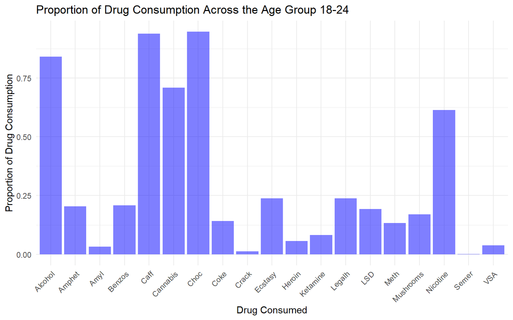

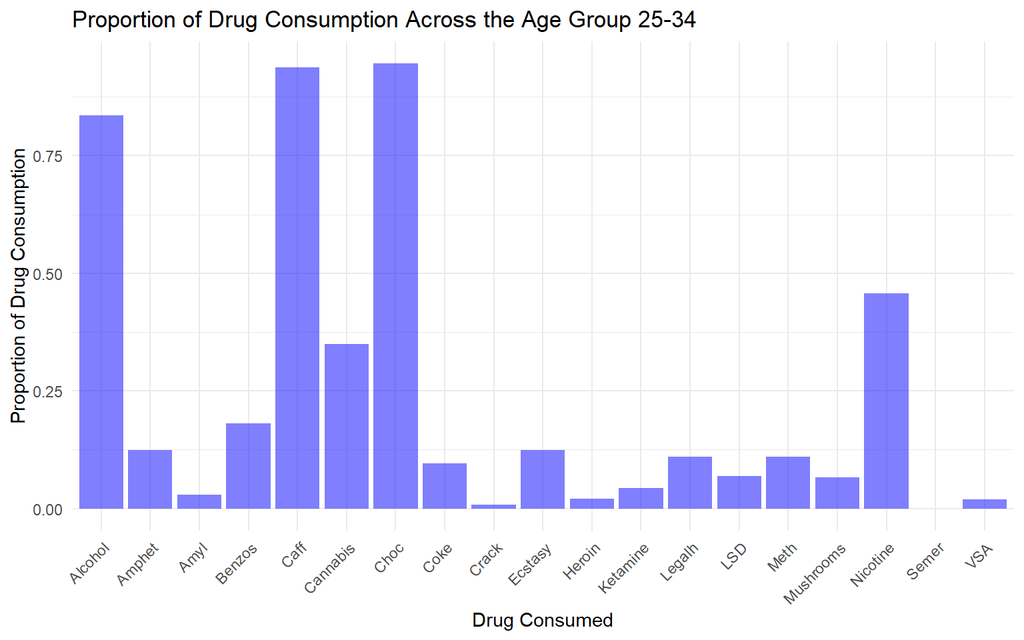

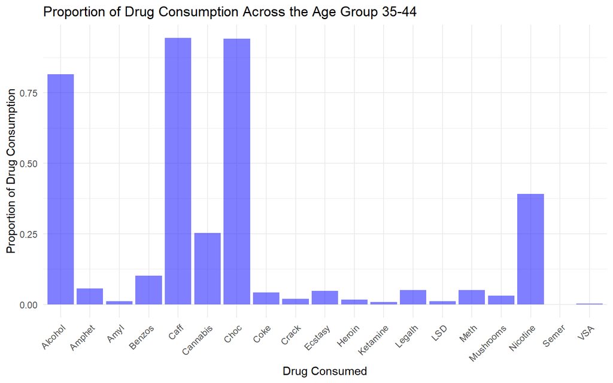

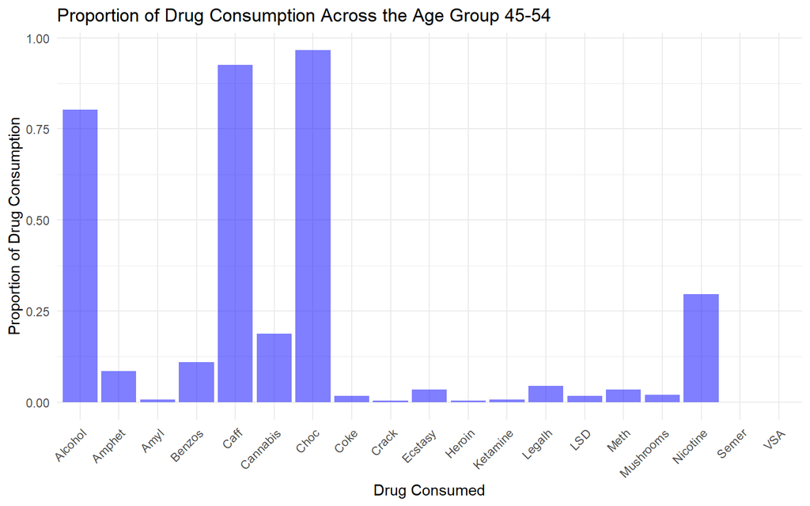

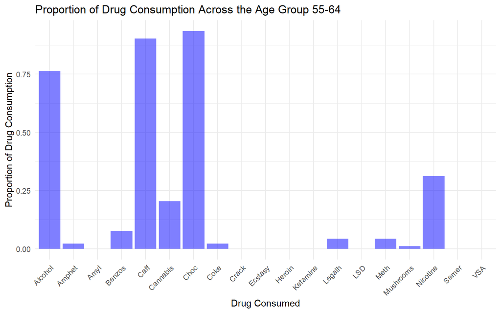

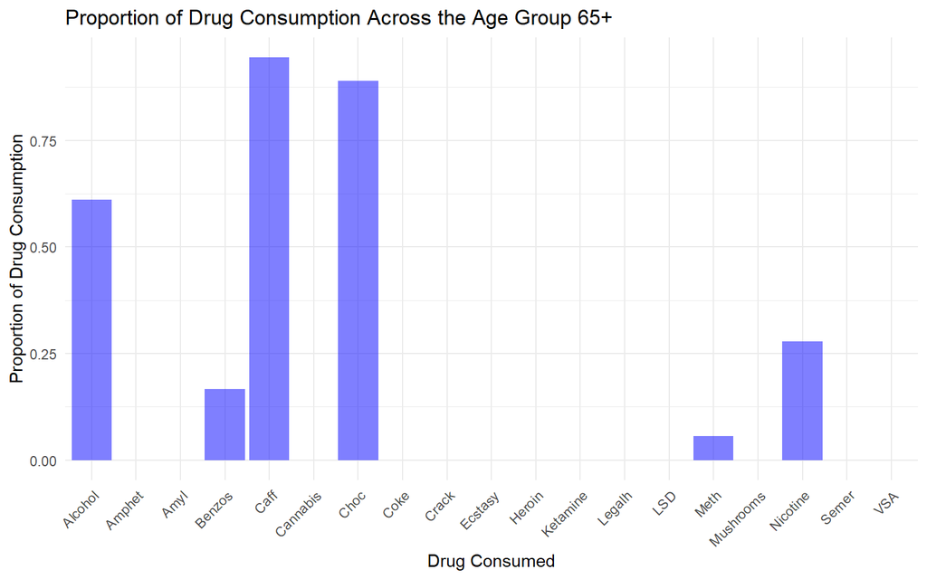

```r
for (i in seq(1, 6)) {
  plot = barPlot[[i]]
  print(plot)
}
```

> For the most part, from looking at all these bar graphs, we can see that the most consistent drug usage would be caffiene, chocolate and Alcohol. I would say caffiene and chocolate aren’t as harmful compared to other drugs like alcohol. Therefore, are focus could be simply just alcohol.

# Proportion of Drug Consumption by Age Group

## Alcohol Usage Across Age groups

- Setting up alcohol proportions by age group

```r
alc = drugProps_df %>% filter(Drugs == "Alcohol")
alc = t(alc)
alc = alc[-1]

alc_prop = tibble(
  Age_Group = age
  ) %>% mutate(
    Alcohol_Prop = as.numeric(alc)
  )

alc_prop
```

```
## # A tibble: 6 × 2
##   Age_Group Alcohol_Prop
##   <chr>            <dbl>
## 1 18-24            0.841
## 2 25-34            0.836
## 3 35-44            0.815
## 4 45-54            0.803
## 5 55-64            0.763
## 6 65+              0.611
```

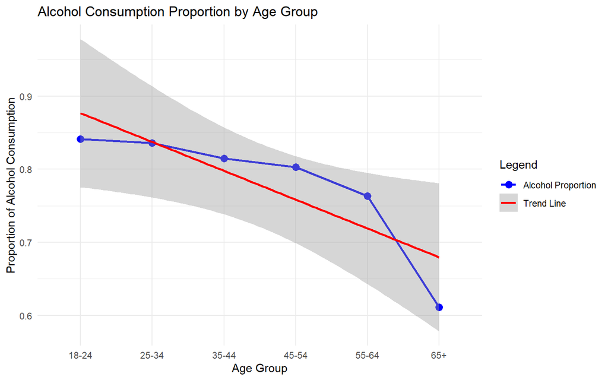

```r
# plot the alcohol consumption proportion by age group
ggplot(alc_prop, aes(x = Age_Group, y = Alcohol_Prop, group = 1)) +
  geom_line(aes(color = "Alcohol Proportion"), size = 1) +
  geom_point(aes(color = "Alcohol Proportion"), size = 3) +
  geom_smooth(
    method = "lm",
    aes(color = "Trend Line"),
    size = 1
  ) +
  scale_color_manual(
    values = c("Alcohol Proportion" = "blue", "Trend Line" = "red"),
    name = "Legend"
  ) +
  labs(
    title = "Alcohol Consumption Proportion by Age Group",
    x = "Age Group",
    y = "Proportion of Alcohol Consumption"
  ) +
  theme_minimal()
```

> This is an obious downward trend in drug consumption as age group increases.

## Amphet Usage Across Age groups

```r
amp = drugProps_df %>% filter(Drugs == "Amphet")
amp = t(amp)
amp = amp[-1]

amp_prop = tibble(
  Age_Group = age
  ) %>% mutate(
    Amphet_Prop = as.numeric(amp)
  )

amp_prop
```

```
## # A tibble: 6 × 2
##   Age_Group Amphet_Prop
##   <chr>           <dbl>
## 1 18-24          0.204
## 2 25-34          0.125
## 3 35-44          0.0562
## 4 45-54          0.0850
## 5 55-64          0.0215
## 6 65+            0
```

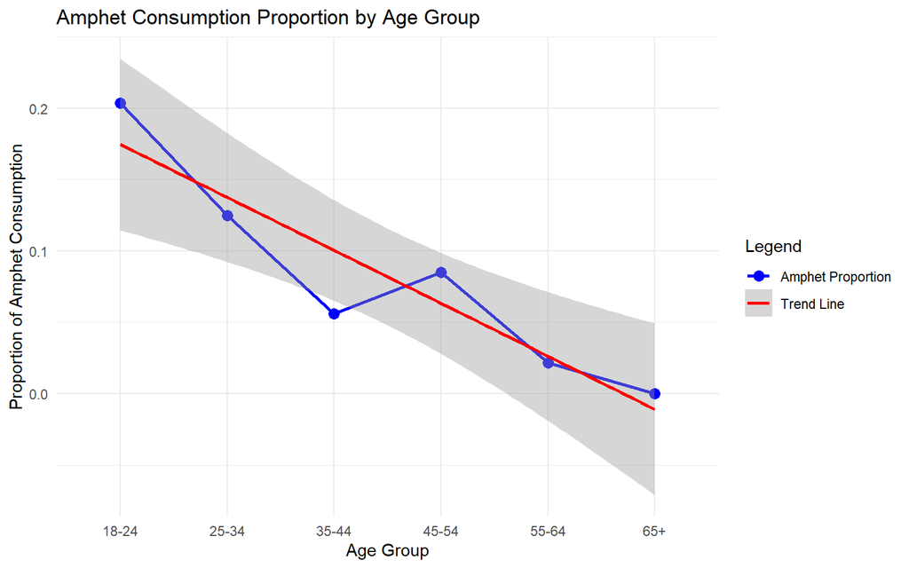

```r
# plot amphet usage by age group
ggplot(amp_prop, aes(x = Age_Group, y = Amphet_Prop, group = 1)) +
  geom_line(aes(color = "Amphet Proportion"), size = 1) +
  geom_point(aes(color = "Amphet Proportion"), size = 3) +
  geom_smooth(
    method = "lm",
    aes(color = "Trend Line"),
    size = 1
  ) +
  scale_color_manual(
    values = c("Amphet Proportion" = "blue", "Trend Line" = "red"),
    name = "Legend"
  ) +
  labs(
    title = "Amphet Consumption Proportion by Age Group",
    x = "Age Group",
    y = "Proportion of Amphet Consumption"
  ) +
  theme_minimal()
```

- create loop to automate plotting for all drugs

```r
drug_plots = list()

for (drug in drugs) {
  # Extract the proportion of the current drug across age groups
  drug_data = drugProps_df %>% filter(Drugs == drug)
  drug_data = t(drug_data)  # Transpose the data
  drug_data = drug_data[-1]  # Remove the header row

  # Create data frame for the current drug
  drug_prop = tibble(
    Age_Group = age
  ) %>% mutate(
    Proportion = as.numeric(drug_data)
  )

  # Create the plot
  plot = ggplot(drug_prop, aes(x = Age_Group, y = Proportion, group = 1)) +
    geom_line(aes(color = "Drug Proportion"), size = 1) +  # Use static label for legend
    geom_point(aes(color = "Drug Proportion"), size = 3) +
    geom_smooth(
      method = "lm",
      aes(color = "Trend Line"),
      size = 1
    ) +
    scale_color_manual(
      values = c(
        "Drug Proportion" = "blue",
        "Trend Line" = "red"
      ),
      name = "Legend"
    ) +
    labs(
      title = paste(drug, "Consumption Proportion by Age Group"),
      x = "Age Group",
      y = paste("Proportion of", drug, "Consumption")
    ) +
    theme_minimal()

  # Add the plot to the list
  drug_plots[[drug]] = plot
}
```

## All Plots for Proportions of Specific Drug Consumption by Age group

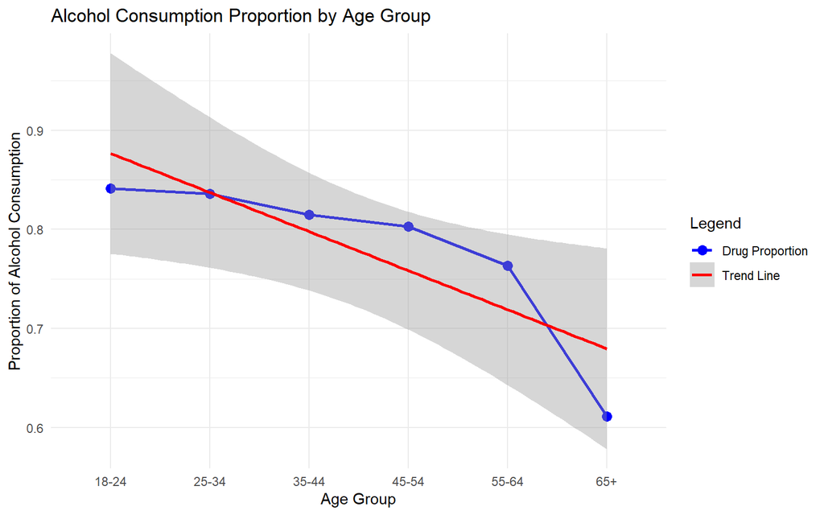

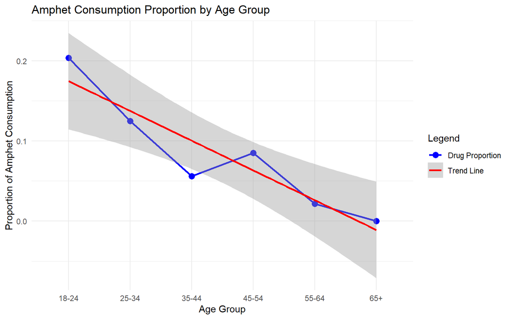

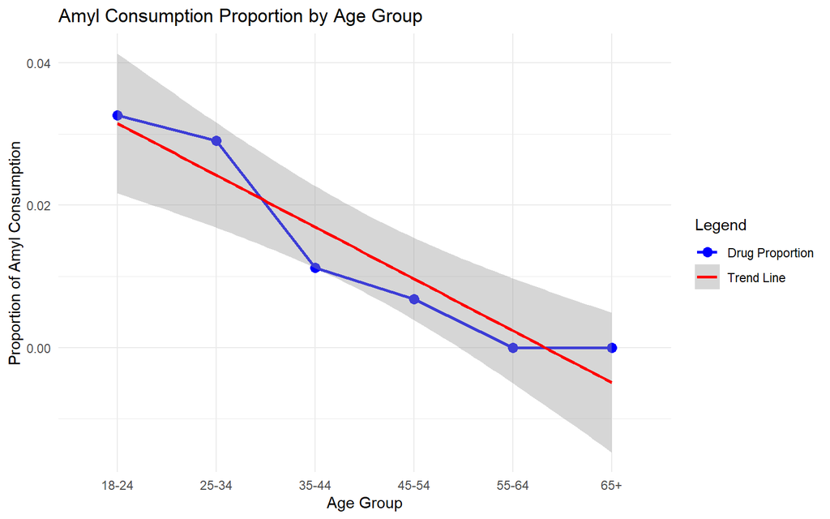

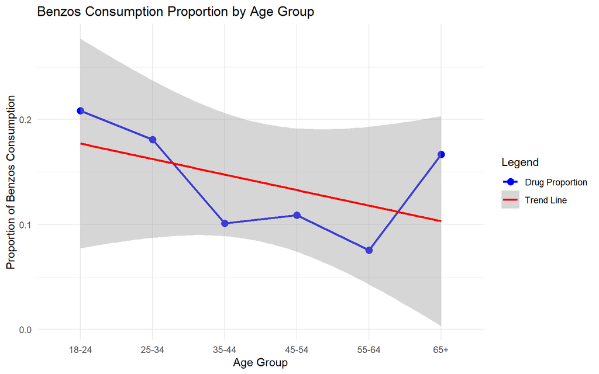

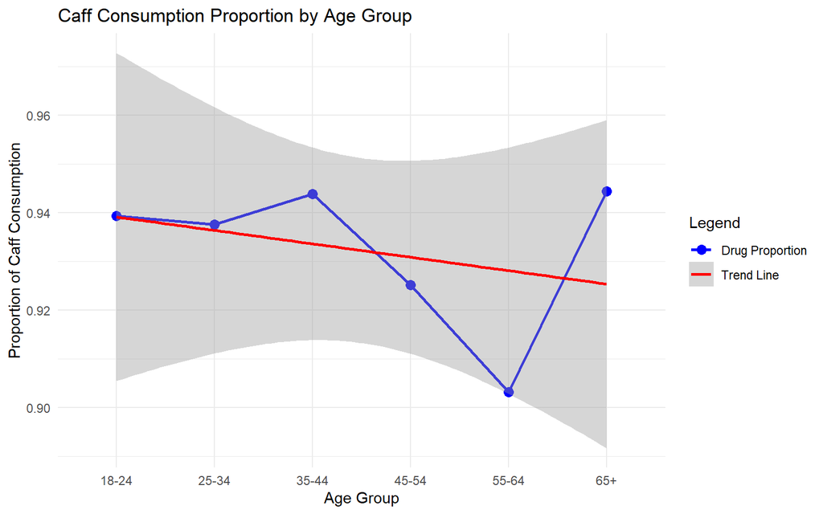

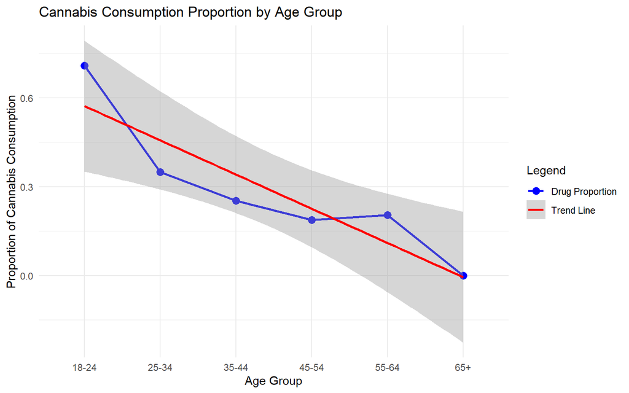

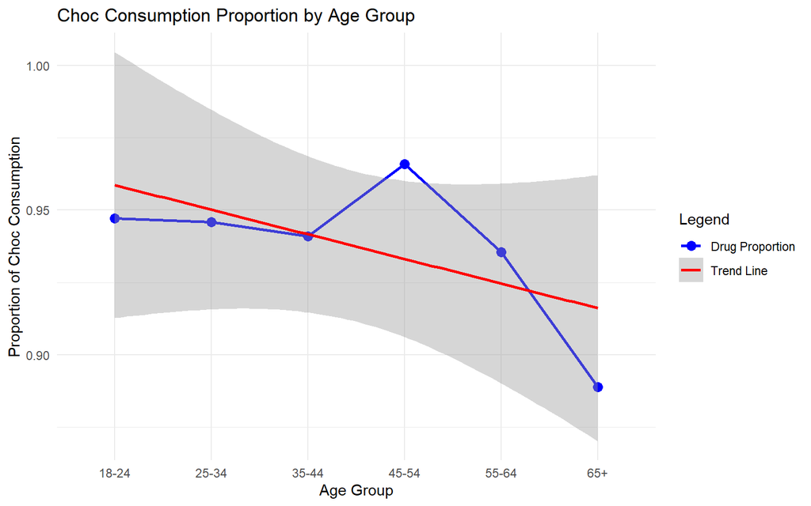

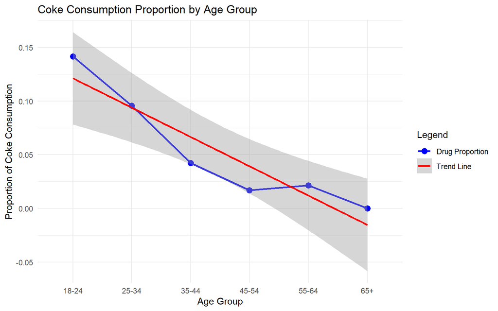

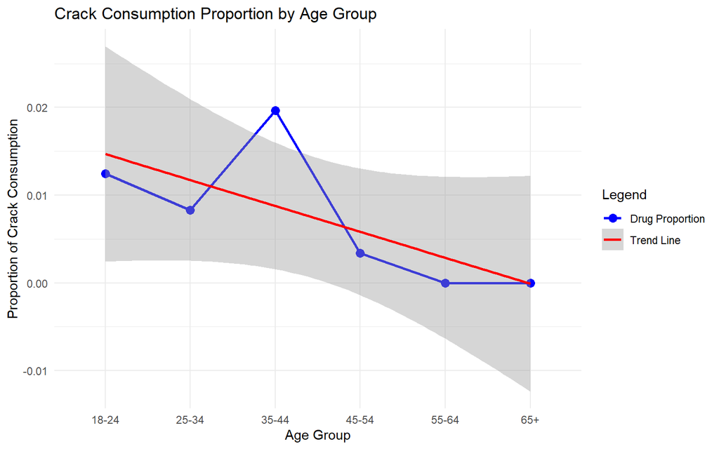

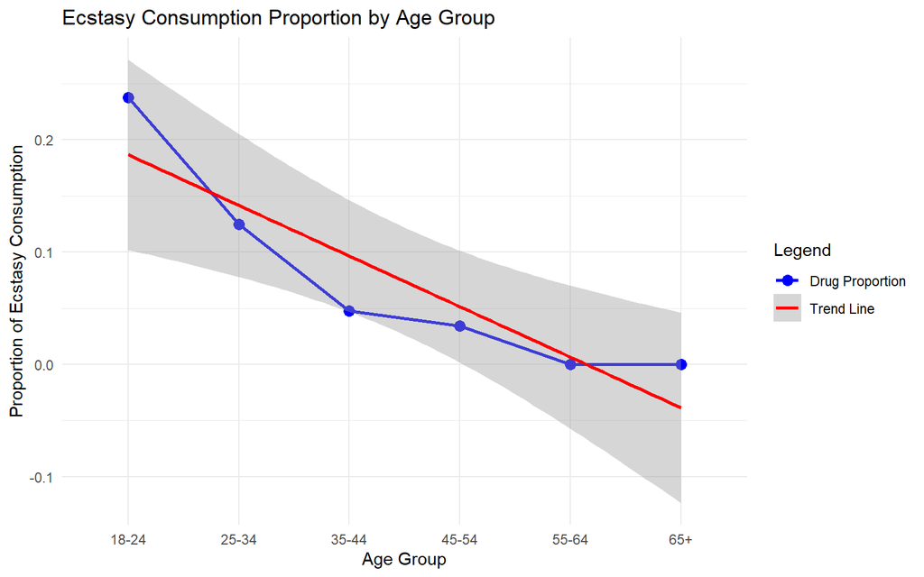

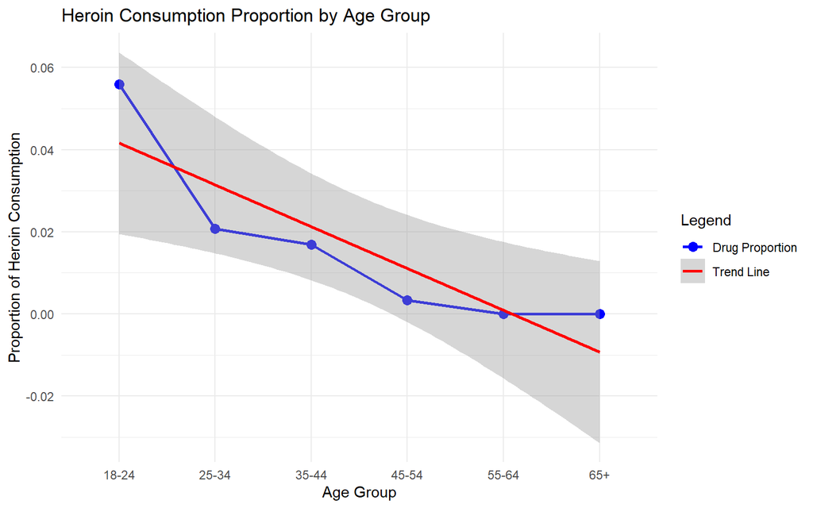

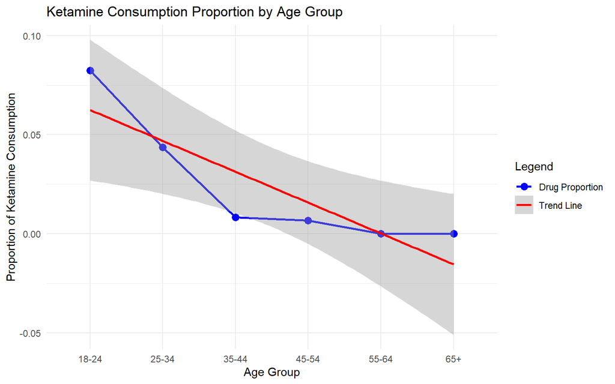

[7 more figures not shown]

```r
for (drug in drugs) {
  print(drug_plots[[drug]])
}
```

# Statistical Analysis

## Primary Question: How does age group correlate with drug usage?

- Purpose: Summarize drug consumption across age groups
- Approach, calculate the standard deviation, and frequency distribution of drug usage (regular vs. less-regular) within each age group.

```r
summary_stats <- Data %>%
  group_by(Age) %>%
  summarise(across(all_of(drugs), list(mean = mean, sd = sd)))
summary_stats
```

```
## # A tibble: 6 × 39
##   Age   Alcohol_mean Alcohol_sd Amphet_mean Amphet_sd Amyl_mean Amyl_sd
##   <chr>        <dbl>      <dbl>       <dbl>     <dbl>     <dbl>   <dbl>
## 1 18-24        0.841      0.366      0.204      0.403   0.0327   0.178
## 2 25-34        0.836      0.371      0.125      0.331   0.0291   0.168
## 3 35-44        0.815      0.389      0.0562     0.231   0.0112   0.106
## 4 45-54        0.803      0.399      0.0850     0.279   0.00680  0.0823
## 5 55-64        0.763      0.427      0.0215     0.146   0        0
## 6 65+          0.611      0.502      0          0       0        0
## # ℹ 32 more variables: Benzos_mean <dbl>, Benzos_sd <dbl>, Caff_mean <dbl>,
## #   Caff_sd <dbl>, Cannabis_mean <dbl>, Cannabis_sd <dbl>, Choc_mean <dbl>,
## #   Choc_sd <dbl>, Coke_mean <dbl>, Coke_sd <dbl>, Crack_mean <dbl>,
## #   Crack_sd <dbl>, Ecstasy_mean <dbl>, Ecstasy_sd <dbl>, Heroin_mean <dbl>,
## #   Heroin_sd <dbl>, Ketamine_mean <dbl>, Ketamine_sd <dbl>, Legalh_mean <dbl>,
## #   Legalh_sd <dbl>, LSD_mean <dbl>, LSD_sd <dbl>, Meth_mean <dbl>,
## #   Meth_sd <dbl>, Mushrooms_mean <dbl>, Mushrooms_sd <dbl>, …
```

### Correlation Analysis

- Quantify the relationship between age and drug usage
- Approach: treat age groups as numeric and calculate the correlation between age and drug proportions for each drug

```r
correlation_results = list()
age_numeric = c(1, 2, 3, 4, 5, 6)  # Numeric encoding for age groups
for (drug in drugs) {
  drug_data = drugProps_df %>% filter(Drugs == drug)
  correlation_results[[drug]] = cor.test(age_numeric, as.numeric(drug_data[2:7]))
}


for (drug in drugs) {
  print(drug)
  print(correlation_results[[drug]])
}
```

```
## [1] "Alcohol"
##
##  Pearson's product-moment correlation
##
## data:  age_numeric and as.numeric(drug_data[2:7])
## t = -3.2737, df = 4, p-value = 0.03068
## alternative hypothesis: true correlation is not equal to 0
## 95 percent confidence interval:
##  -0.9836731 -0.1359280
## sample estimates:
##        cor
## -0.8533526
##
## [1] "Amphet"
##
##  Pearson's product-moment correlation
##
## data:  age_numeric and as.numeric(drug_data[2:7])
## t = -5.1917, df = 4, p-value = 0.006553
## alternative hypothesis: true correlation is not equal to 0
## 95 percent confidence interval:
##  -0.992832 -0.501022
## sample estimates:
##        cor
## -0.9331536
##
## [1] "Amyl"
##
##  Pearson's product-moment correlation
##
## data:  age_numeric and as.numeric(drug_data[2:7])
## t = -6.2358, df = 4, p-value = 0.003369
## alternative hypothesis: true correlation is not equal to 0
## 95 percent confidence interval:
##  -0.9949215 -0.6190752
## sample estimates:
##       cor
## -0.952223
##
## [1] "Benzos"
```

[output cut: 191 more lines]

```
##        cor
## -0.6546537
##
## [1] "VSA"
##
##  Pearson's product-moment correlation
##
## data:  age_numeric and as.numeric(drug_data[2:7])
## t = -3.3204, df = 4, p-value = 0.02937
## alternative hypothesis: true correlation is not equal to 0
## 95 percent confidence interval:
##  -0.9840604 -0.1477867
## sample estimates:
##        cor
## -0.8566081
```

```r
# fisher transformation
# the proportion of variance explained
r = cor(age_numeric, alc_prop$Alcohol_Prop)
r_squared = r^2
cat("Correlation (r) =", r, "R-squared =", r_squared, "\n")
```

```
## Correlation (r) = -0.8533526 R-squared = 0.7282106
```

## Proportion Confidence Intervals (Agresti-Coull Method)

- application: For each drug, compute a 95% Agresti-Coull confidence interval for the proportion of regular users across all age groups.

```r
drugProps = drugProps %>%
  mutate(
    n = nTotal,
    X = usageProp * nTotal,
    p_ac = (X + 2) / (n + 4),
    se_ac = sqrt((p_ac * (1 - p_ac)) / (n + 4)),
    lower = p_ac - qnorm(0.975) * se_ac,
    upper = p_ac + qnorm(0.975) * se_ac
  )
drugProps %>%
  select(Drugs, usageProp, lower, upper)
```

```
## # A tibble: 19 × 4
##    Drugs     usageProp     lower   upper
##    <chr>         <dbl>     <dbl>   <dbl>
##  1 Choc       0.947     0.936    0.957
##  2 Caff       0.936     0.924    0.946
##  3 Alcohol    0.823     0.805    0.839
##  4 Nicotine   0.464     0.442    0.487
##  5 Cannabis   0.418     0.396    0.440
##  6 Benzos     0.159     0.143    0.176
##  7 Legalh     0.128     0.114    0.144
##  8 Ecstasy    0.127     0.113    0.143
##  9 Amphet     0.126     0.112    0.142
## 10 Meth       0.0907    0.0786   0.105
## 11 LSD        0.0881    0.0761   0.102
## 12 Coke       0.0844    0.0726   0.0978
## 13 Mushrooms  0.0844    0.0726   0.0978
## 14 Ketamine   0.0419    0.0337   0.0520
## 15 Heroin     0.0281    0.0215   0.0367
## 16 Amyl       0.0218    0.0160   0.0295
## 17 VSA        0.0180    0.0129   0.0252
## 18 Crack      0.0106    0.00681  0.0165
## 19 Semer      0.000531 -0.000208 0.00338
```

```r
drugProps
```

```
## # A tibble: 19 × 8
##    Drugs     usageProp     n     X    p_ac    se_ac     lower   upper
##    <chr>         <dbl> <int> <dbl>   <dbl>    <dbl>     <dbl>   <dbl>
##  1 Choc       0.947     1885  1786 0.947   0.00518   0.936    0.957
##  2 Caff       0.936     1885  1764 0.935   0.00568   0.924    0.946
##  3 Alcohol    0.823     1885  1551 0.822   0.00880   0.805    0.839
##  4 Nicotine   0.464     1885   875 0.464   0.0115    0.442    0.487
##  5 Cannabis   0.418     1885   788 0.418   0.0113    0.396    0.440
##  6 Benzos     0.159     1885   299 0.159   0.00842   0.143    0.176
##  7 Legalh     0.128     1885   241 0.129   0.00770   0.114    0.144
##  8 Ecstasy    0.127     1885   240 0.128   0.00769   0.113    0.143
##  9 Amphet     0.126     1885   238 0.127   0.00766   0.112    0.142
## 10 Meth       0.0907    1885   171 0.0916  0.00664   0.0786   0.105
## 11 LSD        0.0881    1885   166 0.0889  0.00655   0.0761   0.102
## 12 Coke       0.0844    1885   159 0.0852  0.00642   0.0726   0.0978
## 13 Mushrooms  0.0844    1885   159 0.0852  0.00642   0.0726   0.0978
## 14 Ketamine   0.0419    1885    79 0.0429  0.00466   0.0337   0.0520
## 15 Heroin     0.0281    1885    53 0.0291  0.00387   0.0215   0.0367
## 16 Amyl       0.0218    1885    41 0.0228  0.00343   0.0160   0.0295
## 17 VSA        0.0180    1885    34 0.0191  0.00315   0.0129   0.0252
## 18 Crack      0.0106    1885    20 0.0116  0.00247   0.00681  0.0165
## 19 Semer      0.000531  1885     1 0.00159 0.000916 -0.000208 0.00338
```

## Hypothesis Testing For Single Proportion

- Test whether the proportion of alcohol users differs from a hypothesized value
- Define the null and alternative Hypothesis.
- compute the p-value and interpret the results
- The average proportion across all drugs in the dataset is approximately 0.242

```r
p0 <- 0.24  # hypothesized proportion
X <- drugProps %>% filter(Drugs == "Alcohol") %>% pull(usageProp) * nTotal
n <- nTotal
phat <- X / n
z <- (phat - p0) / sqrt((p0 * (1 - p0)) / n)
p_value <- 2 * (1 - pnorm(abs(z)))  # two-tailed test
cat("Z =", z, "P-value =", p_value, "\n")
```

```
## Z = 59.2477 P-value = 0
```

## Difference in Proportions Between Age Groups

```r
group1 = ageGroup_Prop_DFS[[1]]  # e.g., Age group 18-24
group2 = ageGroup_Prop_DFS[[6]]  # e.g., Age group 65+

p1 = group1 %>% filter(Drugs == "Alcohol") %>% pull(usageProp)
p2 = group2 %>% filter(Drugs == "Alcohol") %>% pull(usageProp)
n1 = nTotals[1]
n2 = nTotals[6]
p_pool = (p1 * n1 + p2 * n2) / (n1 + n2)
z = (p1 - p2) / sqrt(p_pool * (1 - p_pool) * (1/n1 + 1/n2))
p_value = 2 * (1 - pnorm(abs(z)))  # two-tailed test
cat("Z =", z, "P-value =", p_value, "\n")
```

```
## Z = 2.596411 P-value = 0.009420335
```

## Linear Regression Analysis

```r
alc_prop = alc_prop %>%
  mutate(Age_Group = as.numeric(factor(Age_Group, levels = c("18-24", "25-34", "35-44", "45-54", "55-64", "65+"))))


lm_model = lm(Alcohol_Prop ~ as.numeric(Age_Group), data = alc_prop)
summary(lm_model)
```

```
##
## Call:
## lm(formula = Alcohol_Prop ~ as.numeric(Age_Group), data = alc_prop)
##
## Residuals:
##         1         2         3         4         5         6
## -0.035380 -0.001557  0.016723  0.044269  0.044421 -0.068476
##
## Coefficients:
##                       Estimate Std. Error t value Pr(>|t|)
## (Intercept)            0.91618    0.04691  19.531 4.05e-05 ***
## as.numeric(Age_Group) -0.03943    0.01205  -3.274   0.0307 *
## ---
## Signif. codes:  0 '***' 0.001 '**' 0.01 '*' 0.05 '.' 0.1 ' ' 1
##
## Residual standard error: 0.05039 on 4 degrees of freedom
## Multiple R-squared:  0.7282, Adjusted R-squared:  0.6603
## F-statistic: 10.72 on 1 and 4 DF,  p-value: 0.03068
```

```r
confint(lm_model)
```

```
##                             2.5 %       97.5 %
## (Intercept)            0.78594100  1.046420092
## as.numeric(Age_Group) -0.07287462 -0.005989766
```

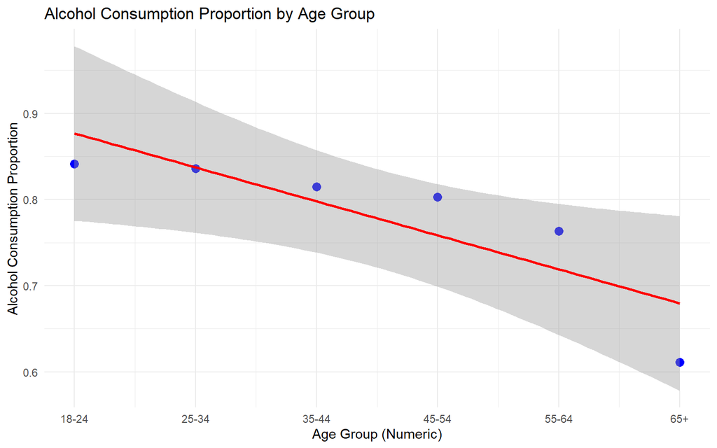

```r
# Scatter plot with regression line
ggplot(alc_prop, aes(x = as.numeric(Age_Group), y = Alcohol_Prop)) +
  geom_point(color = "blue", size = 3) +  # Scatter points
  geom_smooth(method = "lm", se = TRUE, color = "red") +  # Regression line with confidence interval
  labs(
    title = "Alcohol Consumption Proportion by Age Group",
    x = "Age Group (Numeric)",
    y = "Alcohol Consumption Proportion"
  ) +
  theme_minimal() +
  scale_x_continuous(
    breaks = 1:6,  # Match numeric Age_Group to actual groups
    labels = c("18-24", "25-34", "35-44", "45-54", "55-64", "65+")
  )
```

# Hypothesis Testing For Multiple Drugs

```r
# Define hypothesized proportion (p0)
p0 <- 0.24

hypothesis_results <- drugProps %>%
  mutate(
    SE = sqrt((p0 * (1 - p0)) / n),  # Standard error
    Z = (usageProp - p0) / SE,      # Z-statistic
    p_value = 2 * (1 - pnorm(abs(Z))), # Two-tailed p-value
    significant = ifelse(p_value < 0.05, "Yes", "No") # Significance
  ) %>%
  select(Drugs, usageProp, Z, p_value, significant)


hypothesis_results
```

```
## # A tibble: 19 × 5
##    Drugs     usageProp      Z  p_value significant
##    <chr>         <dbl>  <dbl>    <dbl> <chr>
##  1 Choc       0.947     71.9  0        Yes
##  2 Caff       0.936     70.7  0        Yes
##  3 Alcohol    0.823     59.2  0        Yes
##  4 Nicotine   0.464     22.8  0        Yes
##  5 Cannabis   0.418     18.1  0        Yes
##  6 Benzos     0.159     -8.27 2.22e-16 Yes
##  7 Legalh     0.128    -11.4  0        Yes
##  8 Ecstasy    0.127    -11.5  0        Yes
##  9 Amphet     0.126    -11.6  0        Yes
## 10 Meth       0.0907   -15.2  0        Yes
## 11 LSD        0.0881   -15.4  0        Yes
## 12 Coke       0.0844   -15.8  0        Yes
## 13 Mushrooms  0.0844   -15.8  0        Yes
## 14 Ketamine   0.0419   -20.1  0        Yes
## 15 Heroin     0.0281   -21.5  0        Yes
## 16 Amyl       0.0218   -22.2  0        Yes
## 17 VSA        0.0180   -22.6  0        Yes
## 18 Crack      0.0106   -23.3  0        Yes
## 19 Semer      0.000531 -24.3  0        Yes
```

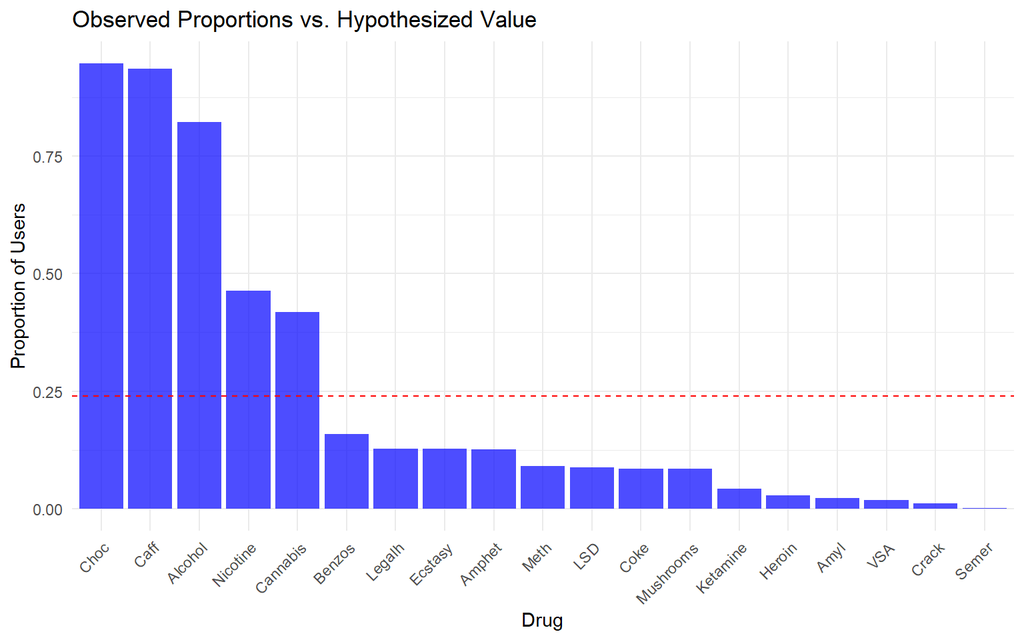

```r
# plot for visuals

ggplot(hypothesis_results, aes(x = reorder(Drugs, -usageProp), y = usageProp)) +
  geom_bar(stat = "identity", fill = "blue", alpha = 0.7) +
  geom_hline(yintercept = p0, linetype = "dashed", color = "red") +
  labs(
    title = "Observed Proportions vs. Hypothesized Value",
    x = "Drug",
    y = "Proportion of Users"
  ) +
  theme(axis.text.x = element_text(angle = 45, hjust = 1))
```

## Comparison Across Age Group Visualization

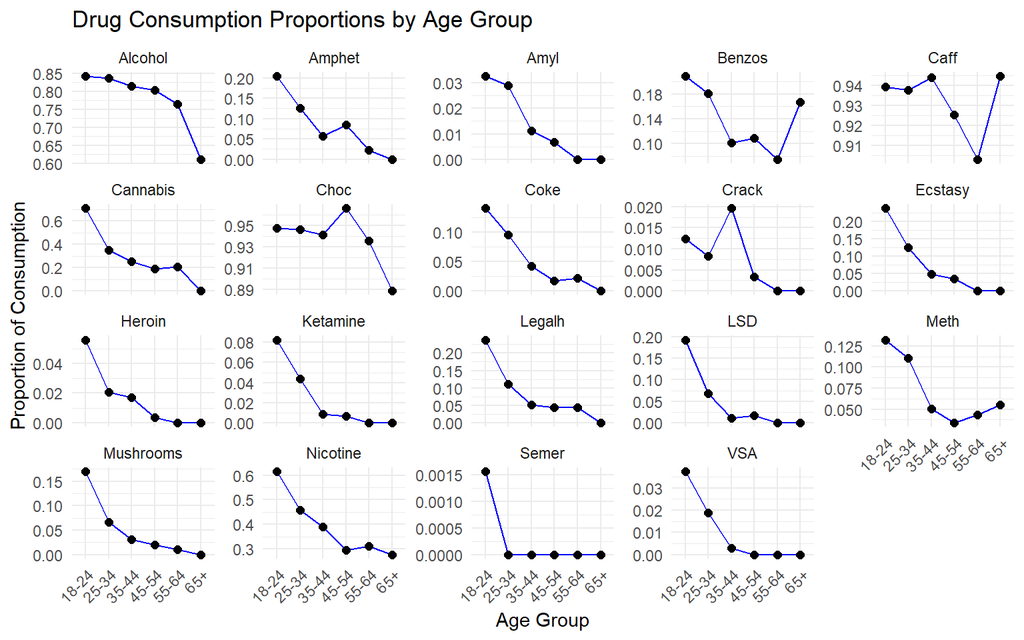

```r
# Prepare data for faceted plot
long_data <- drugProps_df %>%
  pivot_longer(cols = starts_with("usageProp"), names_to = "Age_Group", values_to = "Proportion") %>%
  mutate(Age_Group = factor(Age_Group, labels = age))

# Faceted line plots for each drug
ggplot(long_data, aes(x = Age_Group, y = Proportion, group = 1)) +
  geom_line(color = "blue") +
  geom_point(size = 2) +
  facet_wrap(~Drugs, scales = "free_y") +
  labs(
    title = "Drug Consumption Proportions by Age Group",
    x = "Age Group",
    y = "Proportion of Consumption"
  ) +
  theme_minimal() +
  theme(axis.text.x = element_text(angle = 45, hjust = 1))
```